# ANALISE E APRESENTAÇÃO DE DADOS RELACIONADOS A GERAÇÃO DE ENERGIA LIMPA

Daniele Cristina Lopes Mariano; Eliane Graciela Pilan; Eduardo da Conceição Rosário.

2023.07.04

## 1 Introdução

A queima de combustíveis fosseis para a geração de energia é um dos fatores principais a se levar em consideração quando pensamos em geração de energia limpa. A matriz energética brasileira é em grande parte composta de energia limpa, porém, é dependente da energia produzida por hidroelétricas, para que este cenário mude é essencial que se inicie pesquisas e projetos nas demais formas de geração de energia limpa.

Quando atinge a superfície terrestre, a radiação solar pode ter amplas aplicações em diferentes atividades da sociedade, de forma que, guarda grande importância para a fotossíntese vegetal, com relação a produção de biomassa, ciclo hidrológico, devido aos processos de evaporação e precipitação, refletividade de superfícies, dinâmica da atmosfera e dos oceanos, iluminação passiva e ativa de ambientes e processos fotoquímicos. Além dos processos pontuados, destaca-se também a importância da energia solar para o planejamento e aproveitamento da sua potência energética térmica e fotovoltaica pelo setor elétrico Brasileiro, a fim de garantir o atendimento da demanda crescente de energia elétrica existente no território nacional (IQBAL, 1983; VAREJÃO-SILVA, 2006; PEREIRA et al., 2017).

## 2 Materiais e Métodos

Para a realização da análise, foi utilizado um banco de dados coletados na Polônia, onde contém informações sobre o consumo de energia e parâmetros climáticos, como radiação solar, temperatura, pressão, umidade, velocidade do vento e precipitação.

O database ainda apresenta a coluna “Energy Delta (Wh)” informações sobre mudanças no consumo de energia em um determinado período de tempo, a coluna “GHI” que mede a irradiação solar recebida por uma superfície horizontal, além disso informações sobre a presença de luz solar, período de duração do sol, informações climáticas. O banco de dados foi organizado de forma que seja facilitado o seu desenvolvimento e estudo, para que seja possível realizar uma relação entre a geração de energia renovável e os padrões climáticos ao longo do tempo. De todo o banco de dados disponibilizado, foi utilizado apenas dois anos, sendo os anos de 2017 e 2021, para que fosse possível analisar o diferencial para cada ano.

#### **Tabela 01 -** Variáveis e Descrição

| Nome da Variável | Descrição |
| --- | --- |
| Tempo | O registro de data e hora dos dados registrados no formato AAAA-MM-DD HH:MM:SS. |
| Delta Energia | A diferença no consumo de energia em Watt-hora (Wh) do registro de data e hora anterior para o registro de data e hora atual. |
| GHI | Irradiância Horizontal Global em Watts por metro quadrado (W/m²) medida por um piranômetro, que é a quantidade de radiação solar recebida por uma superfície horizontal. |
| Temperatura | A temperatura em graus Celsius (°C) medida na mesma altura do piranômetro. |
| Pressão | A pressão atmosférica em hectopascais (hPa) medida na mesma altura do piranômetro. |
| Umidade | A umidade relativa em porcentagem (%) medida na mesma altura do piranômetro. |
| Velocidade do Vento | A velocidade do vento em metros por segundo (m/s) medida na mesma altura do piranômetro. |
| Delta Energia | Representa a mudança no consumo de energia durante um determinado período de tempo. |
| Precipitação por Hora | Apresenta a precipitação de chuva por hora. |
| Neve por Hora | Apresenta a quantidade de neve por hora na cidade. |
| Nuvens | A proporção de nuvens no céu. |
| Sol | Se há radiação solar(1) ou não(0). |
| Horas de Sol | A duração da luz do dia |
| Duração do Dia | Quantidade de tempo durante a qual a luz solar está disponível |
| Luz Solar por Hora / Duração do Dia | Quantidade de luz solar em relação a duração do dia. |
| Tipo de Tempo | Fornece informações sobre as condições climáticas gerais, como claro, nublado ou chuvoso |
| Hora | Hora da coleta dos dados. |
| Mês | Mês da coleta dos dados. |

> Abaixo esta descrito os links para o acesso ao GitHub, onde é possivel encontrar toda a documentação da analise e a interação realizada para a elaboração deste projeto. Além disso tambem esta disponivel o link de acesso ao database, para que projeto futuros tenham acesso aos dados utiizados.

**Link de Acesso ao Repositório:** https://github.com/DanieleLopesM/Projeto_Final

**Banco de dados que será utilizado:** https://l1nq.com/gvU8N

### 2.1 Processo de Analise do Banco de Dados

Para iniciar as analises, primeiramente é necessario realizar a inicialização das bibliotecas e pacotes necessarias para o projeto.

```r
library(ggplot2)
library(dplyr)
```

Com as bibliotecas iniciaizadas, realiza-se a leitura dos dados.

```r
dados =  read.csv("dadosR.csv")
```

Foi realizado um filtro para que apenas dados do mês de Janeiro dos anos sejam considerados na analise.

```r
jan =  filter(dados, mes == "1")
jan17 =  filter(jan, ano == "2017")
jan21 =  filter(jan, ano == "2021")
```

Também foi realizada uma média diaria dos valores coletados, já que os dados foram coletados a cada 15 minutos, com dados diarios é possivel analisar melhor a eficiencia diariamente.

```r
media_por_dia_17 <- jan17 %>%
  group_by(dia) %>%
  summarize(media = mean(ghi))

media_por_dia_21 <- jan21 %>%
  group_by(dia) %>%
  summarize(media = mean(ghi))
```

Com a separação dos dados realizada foi elaborado um gráfico utilizando o pacote GGPLOT (Grafico 01), para que fosse possivel analisar as médias de radiação solar, inicialmente do mês de janeiro de cada ano, sendo possivel observar a variação de radiação nos diferentes anos.

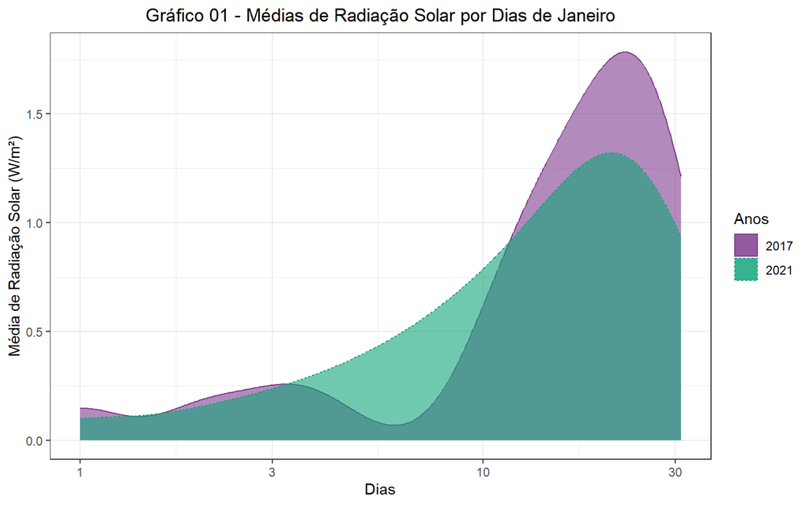

O gráfico apresenta uma variação no nivel de radiação, sendo que esta variação pode ser devido ao clima do local.

Para realizar uma analise das formas de cobertura de céu mais propicias nos anos, foram realizados a separação dos dados de acordo com as especificações dos dias, sendo elas, céu aberto, parcialmente aberto, parcialmente nublado, nublado e chuvoso.

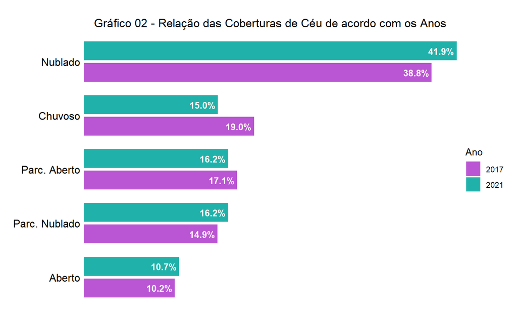

### Referências

IQBAL, M. An Introduction to Solar Radiation. Ontario: Academic Press Canada,1983.

PEREIRA, E. B.; MARTINS, F. R.; GONÇALVES, A. R.; COSTA, R. S.; LIMA. F. J. L.; RUTHER, R.; ABREU, S. L.; TIEPOLO, G. M.; PEREIRA, S. V.; SOUZA, J. G. Atlas Brasileiro de Energia Solar. 2 ed., São José dos Campos: Instituto Nacional de Pesquisas Espaciais, 2017.

VAREJÃO-SILVA, M. A. Meteorologia e Climatologia. 2. ed., Recife: Mário Adelmo Varejão-Silva, 2006. Disponível em: http://www.icat.ufal.br/laboratorio/clima/data/uploads/pdf/METEOROLOGIA_E_CLIM ATOLOGIA_VD2_Mar_2006.pdf. Acesso em: 08 set. 2018.